# R Notebook

```r
setwd('~/Documentos/DataMining/dm-uba.github.io-master/2021/tps_entregables/TP012021/')
```

*Imports*

*Carga datasets*

*Atributos*

-Artista:

```
## [1] "_id"    "Artist"
```

```
## [1] 676   2
```

|  | _id | Artist |
| --- | --- | --- |
| 1 |  | Camila Cabello |
| 2 |  | Post Malone |
| 3 |  | Eminem |
| 4 |  | Bruno Mars |
| 5 |  | Selena Gomez |

No hay artistas repetidos en Artist:

```
## [1] 676   2
```

No hay missings en Artist:

```
##   $oid Artist
##      0      0
```

-Charts

```
## [1] "_id"        "Position"   "Track_Name" "Artist"     "Streams"
## [6] "URL"        "week_start" "week_end"
```

```
## [1] 63600     8
```

No hay missings en charts:

```
##       $oid   Position Track_Name     Artist    Streams        URL week_start
##          0          0          0          0          0          0          0
##   week_end
##          0
```

Cantidad de datos por año en charts:

```
## date
##  2018  2019  2020  2021
## 20400 21200 21200   800
```

Hacemos unique de charts para ver si hay repetidos:

```
## [1] 63600     8
```

```
## [1] 31404     8
```

Hay filas que son la misma pero tienen distinto identificador. Ahora en cada subconjunto vemos si hay repetidos:

agno 2018:

```
## [1] 10200     8
```

```
## [1] 10200     8
```

agno 2019:

```
## [1] 10400     8
```

```
## [1] 10400     8
```

agno 2020:

```
## [1] 10404     8
```

```
## [1] 10404     8
```

agno 2021:

```
## [1] 400   8
```

```
## [1] 400   8
```

Confirmamos que ya no hay repetidos si hacemos unique de charts sin identificador.

- *Tracks*

Cantidad de tracks por artista ordenados de mas tracks a menos (se puede hacer por agno tambien con los subconjuntos de mas arriba):

|  | Artist | Cantidad_tracks |
| --- | --- | --- |
| 497 | Post Malone | 1097 |
| 69 | Billie Eilish | 850 |
| 183 | Ed Sheeran | 816 |
| 659 | XXXTENTACION | 789 |
| 292 | Juice WRLD | 586 |

Post Malone y Billie Eilish tienen mas tracks en los listados en total.

```
##     Artist          Cantidad_tracks
##  Length:677         Min.   :   1.00
##  Class :character   1st Qu.:   4.00
##  Mode  :character   Median :  14.00
##                     Mean   :  46.39
##                     3rd Qu.:  45.00
##                     Max.   :1097.00
```

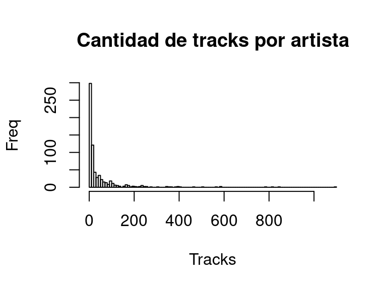

```
## [1] 677   2
```

Discriminando por agno:

-2018

|  | Artist | Cantidad_tracks |
| --- | --- | --- |
| 286 | Post Malone | 420 |
| 365 | XXXTENTACION | 412 |
| 100 | Drake | 296 |
| 105 | Ed Sheeran | 281 |
| 174 | Khalid | 184 |
| 269 | Ozuna | 183 |
| 140 | Imagine Dragons | 179 |
| 348 | Travis Scott | 172 |
| 335 | The Chainsmokers | 167 |
| 111 | Eminem | 129 |

-2019

|  | Artist | Cantidad_tracks |
| --- | --- | --- |
| 38 | Billie Eilish | 457 |
| 293 | Post Malone | 433 |
| 115 | Ed Sheeran | 314 |
| 23 | Ariana Grande | 276 |
| 383 | XXXTENTACION | 227 |
| 295 | Queen | 214 |
| 350 | The Chainsmokers | 187 |
| 191 | Khalid | 168 |
| 151 | Imagine Dragons | 151 |
| 240 | Marshmello | 140 |

-2020

|  | Artist | Cantidad_tracks |
| --- | --- | --- |
| 172 | Juice WRLD | 330 |
| 34 | Bad Bunny | 320 |
| 46 | Billie Eilish | 290 |
| 296 | Post Malone | 238 |
| 113 | Ed Sheeran | 213 |
| 147 | J Balvin | 204 |
| 136 | Harry Styles | 188 |
| 295 | Pop Smoke | 185 |
| 368 | Travis Scott | 179 |
| 27 | Ariana Grande | 169 |

-2021

|  | Artist | Cantidad_tracks |
| --- | --- | --- |
| 58 | Juice WRLD | 12 |
| 92 | Pop Smoke | 12 |
| 5 | Ariana Grande | 10 |
| 10 | Bad Bunny | 10 |
| 12 | Billie Eilish | 10 |
| 34 | Dua Lipa | 8 |
| 35 | Ed Sheeran | 8 |
| 43 | Harry Styles | 8 |
| 59 | Justin Bieber | 8 |
| 80 | Morgan Wallen | 7 |

Si tenemos en cuenta los 5 primeros lugares, Post Malone tuvo mas tracks en la lista por tres agnos seguidos, asi como Ed Sheeran. Billie Eilish va por ese camino. XXXTentation, Juice y Bad Bunny siguen con dos agnos seguidos de tener mas tracks en las listas. XXXTentation fue popular en cuanto a numero de tracks durante 2018 y 2019 pero despues ya no estuvo entre los primeros 5.

- *Streams*

```
##     Min.  1st Qu.   Median     Mean  3rd Qu.     Max.
##  3589018  5151455  6536358  8647701  9846342 71467874
```

El 50% de las reproducciones estan por debajo del orden de las ~6,53 millones de reproducciones y el maximo de reproducciones es del orden de ~71,47 millones de reproducciones. Del histograma podemos ver que las medidas de tendencia central son representativas:

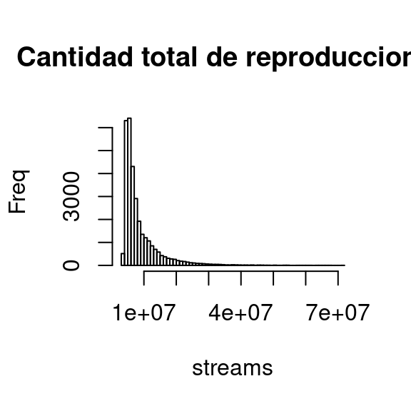

Cantidad media de streams por artista (totales, se podria hacer por año con los subconjuntos hechos mas arriba):

|  | Artist | Streams |
| --- | --- | --- |
| 619 | Tones And I | 21176356 |
| 535 | SAINt JHN | 19241855 |
| 651 | Wham! | 18953450 |
| 248 | Internet Money | 17534199 |
| 261 | Jawsh 685 | 17492221 |
| 498 | Powfu | 16942971 |
| 387 | Mariah Carey | 16608649 |
| 6 | 24kGoldn | 16235710 |
| 79 | Bobby Helms | 15593486 |
| 272 | Joel Corry | 15208331 |

Se meten artistas antiguos en el ranking de popularidad por reproducciones.

```
##     Artist             Streams
##  Length:677         Min.   : 3747900
##  Class :character   1st Qu.: 5097888
##  Mode  :character   Median : 6162743
##                     Mean   : 6832971
##                     3rd Qu.: 7799853
##                     Max.   :21176356
```

Las medidas centrales son representativas. El 50% de los artistas tienen en promedio por debajo de ~6,16 millones de reproducciones.

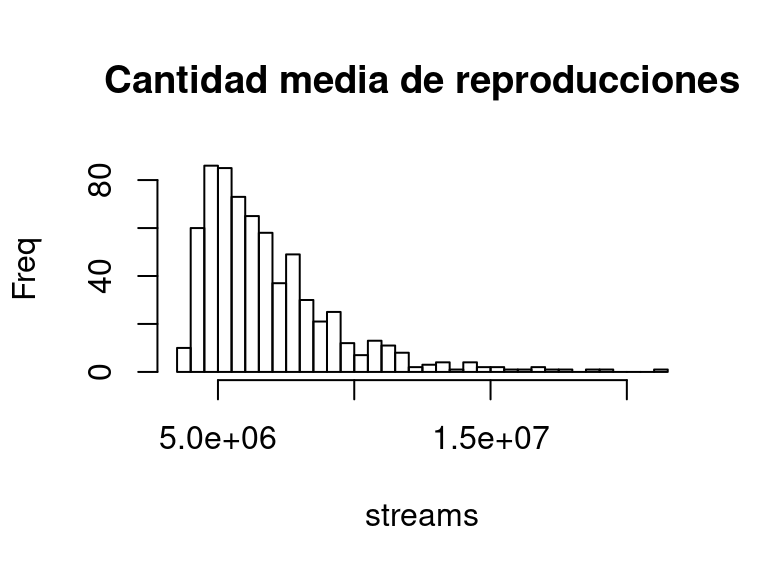

Del histograma podemos ver que las medidas de tendencia central son representativas.

Si consideramos el maximo de reproducciones para cada artista:

|  | Artist | Streams |
| --- | --- | --- |
| 42 | Ariana Grande | 71467874 |
| 173 | Drake | 67499798 |
| 554 | Shawn Mendes | 67237638 |
| 466 | Olivia Rodrigo | 65873080 |
| 183 | Ed Sheeran | 58370367 |
| 387 | Mariah Carey | 53401383 |
| 54 | Bad Bunny | 53344093 |
| 611 | The Weeknd | 52375259 |
| 619 | Tones And I | 52055226 |
| 69 | Billie Eilish | 50342324 |

[output cut: 667 more lines]

Al cambiar a maximo de reproducciones se meten mas artistas nuevos. Varios tambien tienen muchos tracks en las listas, otros se ve que son populares por una cancion (o algunas pocas) que pegaron.

```
##     Artist             Streams
##  Length:677         Min.   : 3768492
##  Class :character   1st Qu.: 5623237
##  Mode  :character   Median : 8344055
##                     Mean   :12446504
##                     3rd Qu.:14838238
##                     Max.   :71467874
```

Para el 50% de artistas su cancion mas escuchada tiene por debajo de ~8,34 millones de reproducciones. El maximo es de ~71,47 millones.

Del histograma podemos ver que las medidas de tendencia central son representativas:

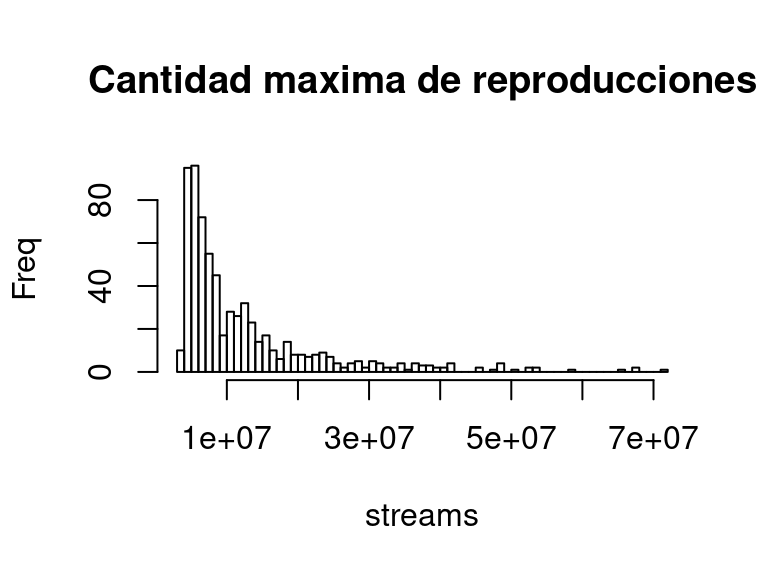

- *Canciones top*

Hay 39 canciones que han ocupado el primer lugar (total, tambien se puede discriminar por año):

|  | Position | Track_Name | Artist | agno |
| --- | --- | --- | --- | --- |
| 1 | 1 | Havana (feat. Young Thug) | Camila Cabello | 2018 |
| 201 | 1 | God's Plan | Drake | 2018 |
| 2201 | 1 | Call Out My Name | The Weeknd | 2018 |
| 2601 | 1 | Nice For What | Drake | 2018 |
| 3001 | 1 | Better Now | Post Malone | 2018 |

por agno:

-2018

|  | Position | Track_Name | Artist | agno |
| --- | --- | --- | --- | --- |
| 1 | 1 | Havana (feat. Young Thug) | Camila Cabello | 2018 |
| 201 | 1 | God's Plan | Drake | 2018 |
| 2201 | 1 | Call Out My Name | The Weeknd | 2018 |
| 2601 | 1 | Nice For What | Drake | 2018 |
| 3001 | 1 | Better Now | Post Malone | 2018 |
| 3401 | 1 | This Is America | Childish Gambino | 2018 |
| 4401 | 1 | SAD! | XXXTENTACION | 2018 |
| 4801 | 1 | Nonstop | Drake | 2018 |
| 5001 | 1 | In My Feelings | Drake | 2018 |
| 6601 | 1 | Lucky You (feat. Joyner Lucas) | Eminem | 2018 |

-2019

|  | Position | Track_Name | Artist | agno |
| --- | --- | --- | --- | --- |
| 10201 | 1 | Sunflower - Spider-Man: Into the Spider-Verse | Post Malone | 2019 |
| 10801 | 1 | 7 rings | Ariana Grande | 2019 |
| 12801 | 1 | bad guy | Billie Eilish | 2019 |
| 14001 | 1 | I Don't Care (with Justin Bieber) | Ed Sheeran | 2019 |
| 15201 | 1 | Señorita | Shawn Mendes | 2019 |
| 17401 | 1 | Circles | Post Malone | 2019 |
| 18201 | 1 | HIGHEST IN THE ROOM | Travis Scott | 2019 |
| 18401 | 1 | Dance Monkey | Tones And I | 2019 |
| 18801 | 1 | Lose You To Love Me | Selena Gomez | 2019 |

-2020

|  | Position | Track_Name | Artist | agno |
| --- | --- | --- | --- | --- |
| 20801 | 1 | Dance Monkey | Tones And I | 2020 |
| 22001 | 1 | The Box | Roddy Ricch | 2020 |
| 22401 | 1 | Blinding Lights | The Weeknd | 2020 |
| 24201 | 1 | THE SCOTTS | THE SCOTTS | 2020 |
| 25001 | 1 | Rain On Me (with Ariana Grande) | Lady Gaga | 2020 |
| 25201 | 1 | ROCKSTAR (feat. Roddy Ricch) | DaBaby | 2020 |
| 26801 | 1 | cardigan | Taylor Swift | 2020 |
| 27001 | 1 | Savage Love (Laxed - Siren Beat) | Jawsh 685 | 2020 |
| 27401 | 1 | WAP (feat. Megan Thee Stallion) | Cardi B | 2020 |
| 28401 | 1 | Mood (feat. iann dior) | 24kGoldn | 2020 |

-2021

|  | Position | Track_Name | Artist | agno |
| --- | --- | --- | --- | --- |
| 31401 | 1 | DÁKITI | Bad Bunny | 2021 |
| 31601 | 1 | drivers license | Olivia Rodrigo | 2021 |

Se observa que las canciones top cambian a cada agno. Se podria discriminar tambien por temporada.

Artistas con mas canciones en el primer lugar:

|  | Artist | Canciones_Top |
| --- | --- | --- |
| 10 | Drake | 4 |
| 2 | Ariana Grande | 3 |
| 18 | Post Malone | 3 |
| 3 | Bad Bunny | 2 |
| 24 | The Weeknd | 2 |
| 1 | 24kGoldn | 1 |
| 4 | Billie Eilish | 1 |
| 5 | Camila Cabello | 1 |
| 6 | Cardi B | 1 |
| 7 | Childish Gambino | 1 |

De nuevo repiten varios de los artistas que tienen mas canciones en las listas y con mas reproducciones, pero las canciones que son top para cada artista son unas pocas.